# Project Milestone 2: Detailed Analysis of Chosen Data Set & High-level Product Development Plan

Dumbudore’s Army (ChiaoNi Sun, Lin Zhai, Sifan Chen)

4/13/2017

## 1. Product

*Briefly describe the data product you intend to build (You can copy this from previous submissions) (5 pts)*

We intend to build the app that helps people to get their used-car value estimations or to get used-car price which they are looking for. Basically, a user needs to choose or type make, model, location, year and mileage. Then the app can predict the price range of the given used car so that the user can judge whether the price is reasonable or not.

The application we want to build takes the following inputs:

- year of make
- brand
- model
- transmission
- mileage
- zip code

We will output an estimated price range based on user inputs.

- lowest value
- highest value
- most likely value

In addition to the basic estimation, we plan to use more features to narrow down the estimation range. An advanced function is to ask users to enter detailed information such as vehicle condition and equipment. Therefore, the app is able to return more accurate value to users.

More dimensions we ask users to help narrow down the range can be:

- engine type
- vehicle type (limo, economy)
- repair/damage

## 2. Persona

*Describe the experience of an end-user using your capability in a data product. Be specific but no need for any visuals. (20 pts)*

Eric, who had worked in California for five years, received one exciting offer from Baidu in Beijing. He had made up his mind to leave the U.S. and go back to his mother country. So he was busy at selling his furniture, the TV, and his white Toyota Camry 2009. What troubled Eric the most is to deal with his car which he had spent money and time in maintenance. Some of his friends recommended the app to him because they think the estimated price on this app is more reasonable. Therefore, Eric downloaded this app and then a form popped up on his screen to ask if he wanted to fill a few information to get vehicle value estimation. Eric typed ‘Toyota’ as the Make, ‘Camry’ as the Model, ‘2009’ as the Year, ‘San Francisco’ as the Location, and ‘75283’ as the Mileage. Then this app gave a price range back to Eric and asked if he was willing to provide more vehicle information to narrow down the price range. Other information like horsepower, fuel type, car accident were needed to get the smaller range of estimated price.

After Eric got the smaller range of his vehicle value estimation, he was asked if he would like to join the app membership for free to get more services, like car recommendation, saving price quote request, and saving search history. There was another option if Eric would like to pay small fee to become VIP in order to get transaction history of similar vehicles.

## 3. Outcome and Predictors

*Describe the outcome and explanatory variables used in your project. Analyze them with R using the regression techniques you learned in class and comment on the relationship between the outcome and each explanatory variable. Comment on intercept, slope, p-value and R-squared statistics. (25 pts)*

Read the data from file.

```r
library(readr)
autos <- read_csv("~/dataset/autos.csv")
```

We selected three variables as independent parameters. 1. mileage (kilometer) 2. transmission (gearbox) 3. car age (year of registration)

### 1st Variable: Mileage

Identify the 1st variable: the kilometer (shows how many kilometers the car was driven).

```r
lm1 <- lm(price ~ kilometer, data = autos)
summary(lm1)
```

```
##
## Call:
## lm(formula = price ~ kilometer, data = autos)
##
## Residuals:
##    Min     1Q Median     3Q    Max
## -17455  -3205  -1756   1645 894446
##
## Coefficients:
##               Estimate Std. Error t value Pr(>|t|)
## (Intercept)  1.793e+04  5.274e+01   340.0   <2e-16 ***
## kilometer   -9.386e-02  4.000e-04  -234.7   <2e-16 ***
## ---
## Signif. codes:  0 '***' 0.001 '**' 0.01 '*' 0.05 '.' 0.1 ' ' 1
##
## Residual standard error: 8890 on 324062 degrees of freedom
## Multiple R-squared:  0.1452, Adjusted R-squared:  0.1452
## F-statistic: 5.506e+04 on 1 and 324062 DF,  p-value: < 2.2e-16
```

From the summary, kilometer has a strong influence on the price outcome.
$$Intercept = 1.793e04$$

When there is only one variable (kilometer), the intercept value is when the variable equals 0. In this case, when the car is never drove, the mean price is the intercept value.

$$Slope = -9.386e(-02)$$
Kilometer has a negative correlation with price.

### 2nd Variable: Transmission (Categorical)

```r
lm2 <- lm(price ~ kilometer+gearbox, data = autos)
summary(lm2)
```

```
##
## Call:
## lm(formula = price ~ kilometer + gearbox, data = autos)
##
## Residuals:
##    Min     1Q Median     3Q    Max
## -21445  -2493  -1143   1751 895999
##
## Coefficients:
##                  Estimate Std. Error t value Pr(>|t|)
## (Intercept)     2.191e+04  5.725e+01   382.8   <2e-16 ***
## kilometer      -9.116e-02  3.868e-04  -235.7   <2e-16 ***
## gearboxmanuell -5.546e+03  3.638e+01  -152.4   <2e-16 ***
## ---
## Signif. codes:  0 '***' 0.001 '**' 0.01 '*' 0.05 '.' 0.1 ' ' 1
##
## Residual standard error: 8587 on 324061 degrees of freedom
## Multiple R-squared:  0.2024, Adjusted R-squared:  0.2024
## F-statistic: 4.112e+04 on 2 and 324061 DF,  p-value: < 2.2e-16
```

$$Intercept = 2.191e04$$
With the categorical variable gearbox (which means types of transmission, manual, or auto), the intercept is when kilometer equals zero and gearbox is auto.

$$Slope = -5.546e(03)$$
When transmission is manual, it adds a negative slope value to the price.

$$R Squred = 0.2024$$
Comparing to the previous model, the match ratio is raised to 20.24%.

### 3rd Variable: Car Age

```r
lm3 <- lm(price ~ kilometer + gearbox + yearOfRegistration, data = autos)
summary(lm3)
```

```
##
## Call:
## lm(formula = price ~ kilometer + gearbox + yearOfRegistration,
##     data = autos)
##
## Residuals:
##    Min     1Q Median     3Q    Max
## -22569  -2777   -734   1382 906550
##
## Coefficients:
##                      Estimate Std. Error t value Pr(>|t|)
## (Intercept)        -4.730e+05  4.502e+03  -105.1   <2e-16 ***
## kilometer          -7.757e-02  3.994e-04  -194.2   <2e-16 ***
## gearboxmanuell     -5.237e+03  3.584e+01  -146.1   <2e-16 ***
## yearOfRegistration  2.460e+02  2.238e+00   109.9   <2e-16 ***
## ---
## Signif. codes:  0 '***' 0.001 '**' 0.01 '*' 0.05 '.' 0.1 ' ' 1
##
## Residual standard error: 8432 on 324060 degrees of freedom
## Multiple R-squared:  0.2311, Adjusted R-squared:  0.2311
## F-statistic: 3.247e+04 on 3 and 324060 DF,  p-value: < 2.2e-16
```

$$Intercept = -4.730e05$$
The intercept value shows the price when kilometer is 0, auto transmission and registered on year 0000.

$$Slope = 2.460e(02)$$
The increase of year registration value, the more expensive the car is.

$$R Squred = 0.2311$$
The match ratio is raised by 3%.

The final regression model equation.

$$Price = (-4.730e05) + (-7.757e(-02) * kilometer + (-5.237e(03)) * manual + 2.460e(02) * yearOfRegistration$$

We realize it’s not an ideal model to use. We will look into other datasets or use different model.

## 4. Boxplots and Scatterplots

*Create boxplots and scatterplots including confidence and prediction intervals for the relationship of the outcome with each predictor. (25 pts)*

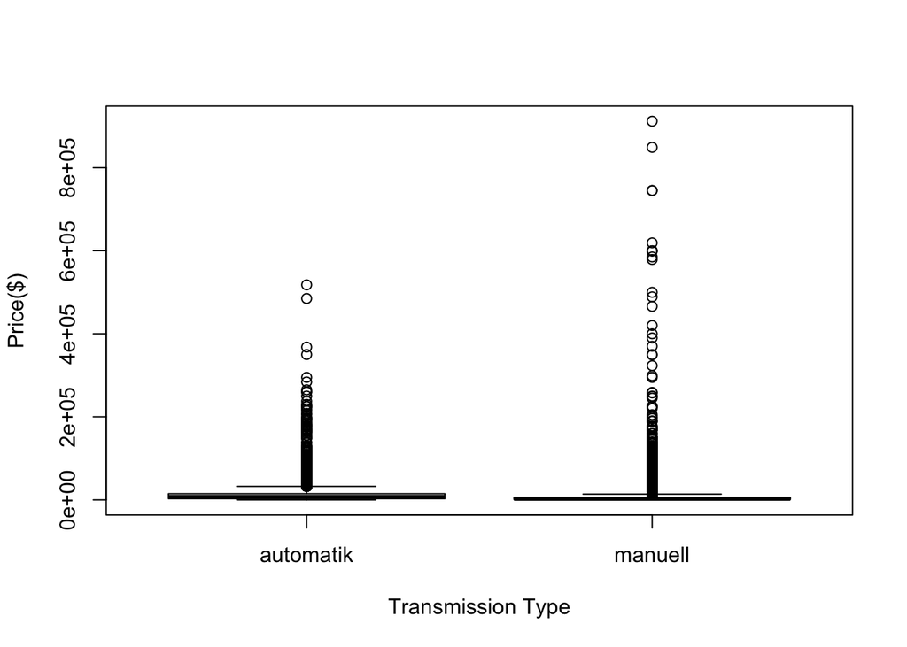

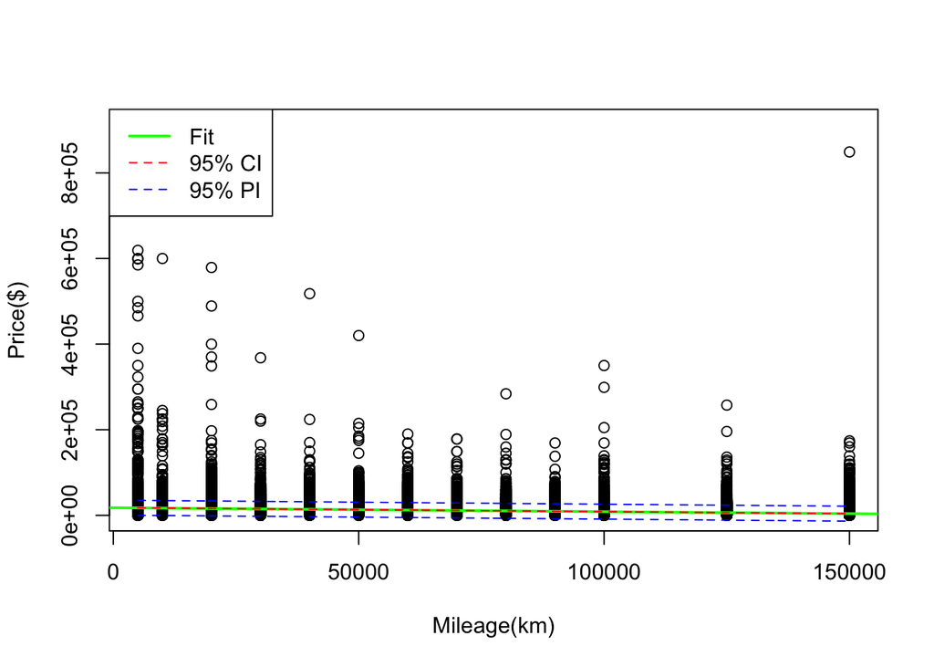

## 5. Comparing with Visual Observation

*Compare your findings from regression analysis with your visual observations from the plot. Refine your strategy if necessary. (25 pts)*

Our problem is in our dataset, we have more categorical data than numeric ones. We found only two numeric variables (mileage and age).

The next step, instead of looking for a better model, we may change to a different dataset and restart.